# ROC analysis of a generic diagnostic test

In this notebook, we analyze sample data for a diagnostic test to determine the receiver operating characteristic (ROC).

First, read in the data from the csv:

```r
df <- read.csv("raw_data_for_ROC.csv", header=TRUE)
head(df)
```

|  | sample_name | sample_status | sample_status_code | genome_copies | sensor |
| --- | --- | --- | --- | --- | --- |
| 1 | S1 | negative | 0 | 0 | 553 |
| 2 | S2 | negative | 0 | 0 | 1011 |
| 3 | S3 | negative | 0 | 0 | 613 |
| 4 | S4 | negative | 0 | 0 | 558 |
| 5 | S5 | negative | 0 | 0 | 211 |
| 6 | S6 | negative | 0 | 0 | 397 |

Load the package “pROC”:

```r
library(pROC)
'citation("pROC")'
```

```
[1] "citation(\"pROC\")"
```

Build an roc object by calling the roc() function and passing the true outcome and the predictor as parameters. In this case, that is the sample_status_code and the sensor reading, respectively. We can also directly plot an ROC by directly calling plot.roc:

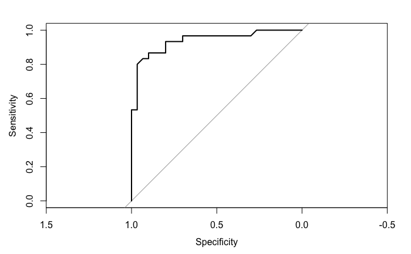

```r
my_roc_obj <- roc(df$sample_status_code, df$sensor)
plot.roc(df$sample_status_code, df$sensor)
```

We get the area under the curve (AUC) as an indicator of the diagnostics overall predictive value (perfect classifier would yield an AUC = 1). R integrates the area under the curve via the trapezoidal rule for estimating integrals. To get the result, we call the function auc() and pass it the roc object and specify the parameter partial.auc = FALSE.

```r
auc(my_roc_obj, partial.auc=FALSE)
```

```
Area under the curve: 0.9389
```

```r
library(ggplot2)
```